# Homework #6

Jaxon Stuhr

2022-12-01

## Excercise 1

Read in data, clean, split, fold, and build recipe,

```r
set.seed(7321)
# read in pokemon data, set seed
pokemon_raw = read_csv(here("data", "Pokemon.csv"))
# clean names
pokemon_clean = pokemon_raw %>%
  clean_names()
pokemon = pokemon_clean %>%
# filter for only common types
  filter(type_1 %in% c("Bug", "Fire", "Grass", "Normal", "Water", "Psychic")) %>%
# convert type_1, legendary, generation to factors
  mutate(type_1 = factor(type_1)) %>%
  mutate(legendary = factor(legendary, levels = c("TRUE", "FALSE"))) %>%
  mutate(generation = factor(generation)) %>%
  select(-number, -total)
# split data into training, testing sets
pokemon_split <- initial_split(pokemon, prop = 0.75,
                                strata = "type_1")
pokemon_train <- training(pokemon_split)
pokemon_test <- testing(pokemon_split)
# fold training set w V=5
pokemon_folds <- vfold_cv(pokemon_train, v = 5, strata = "type_1")
# build recipe
# generate recipe to predict type_1
pokemon_recipe <- recipe(type_1 ~ legendary + generation + sp_atk + attack + speed + defense + hp + sp_def, data = pokemon_train) %>%
  # dummy vars for nominal predictors
  step_dummy(legendary, generation) %>%
  # center
  step_center(all_predictors()) %>%
  # scale
  step_scale(all_predictors())
```

## Excercise 2

Correlation matrix of training set.

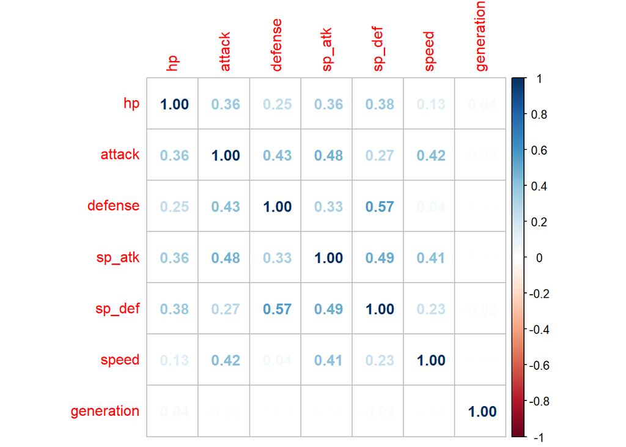

```r
# build correlation matrix of numeric predictors, display as corrplot
# consider generation as numeric predictor
pokemon_cor = cor(pokemon_train %>% mutate(generation = as.numeric(generation)) %>% select(where(is.numeric)))
corrplot(pokemon_cor, method = "number")
```

```r
# plot frequencies of categorical predictors to check for correlation
pokemon_categorical = pokemon_train %>%
  group_by(legendary) %>%
  summarise(count = n(),
            mean_hp = mean(hp),
            mean_attack = mean(attack),
            mean_defense = mean(defense),
            mean_sp_atk = mean(sp_atk),
            mean_sp_def = mean(sp_def),
            mean_speed = mean(speed))

pokemon_categorical
```

```
## # A tibble: 2 × 8
##   legendary count mean_hp mean_attack mean_defense mean_sp_atk mean_sp…¹ mean_…²
##   <fct>     <int>   <dbl>       <dbl>        <dbl>       <dbl>     <dbl>   <dbl>
## 1 TRUE         18    89.1       114.          94.3       114.      102.    108.
## 2 FALSE       323    68.4        69.8         67.3        70.1      67.6    65.4
## # … with abbreviated variable names ¹mean_sp_def, ²mean_speed
```

We can observe minor correlations between some numeric predictors, but all <60%, with the highest being sp_def and defense, which makes sense. We additionally see that legendary status is correlated with higher values of all numeric predictors.

## Excercise 3

Decision Tree model and workflow, tuning cost_complexity. Then autoplot.

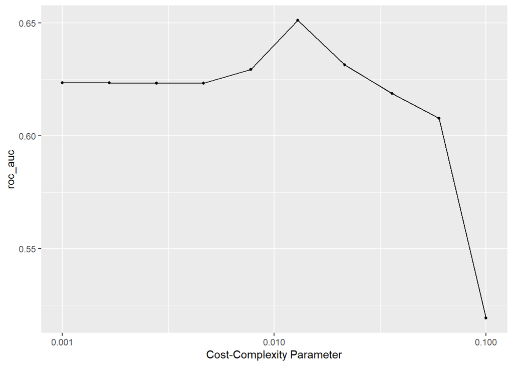

```r
pokemon_tree_model <- decision_tree() %>%
  set_engine("rpart") %>%
  set_mode("classification")

pokemon_workflow <- workflow() %>%
  add_model(pokemon_tree_model %>% set_args(cost_complexity = tune())) %>%
  add_recipe(pokemon_recipe)

param_grid <- grid_regular(cost_complexity(range = c(-3, -1)), levels = 10)

tune_res <- tune_grid(
  pokemon_workflow,
  resamples = pokemon_folds,
  grid = param_grid,
  metrics = metric_set(roc_auc)
)

autoplot(tune_res)
```

A single decision tree performs best with a cost complexity parameter of ~.01, however, it performs relatively well for all low cost-complexity parameters and then performance drops off for higher ones.

## Excercise 4

ROC AUC of best performing tree.

```r
collect_metrics(tune_res) %>% arrange(mean)
```

```
## # A tibble: 10 × 7
##    cost_complexity .metric .estimator  mean     n std_err .config
##              <dbl> <chr>   <chr>      <dbl> <int>   <dbl> <chr>
##  1         0.1     roc_auc hand_till  0.519     5 0.0192  Preprocessor1_Model10
##  2         0.0599  roc_auc hand_till  0.608     5 0.00561 Preprocessor1_Model09
##  3         0.0359  roc_auc hand_till  0.619     5 0.0127  Preprocessor1_Model08
##  4         0.00278 roc_auc hand_till  0.623     5 0.00812 Preprocessor1_Model03
##  5         0.00464 roc_auc hand_till  0.623     5 0.00812 Preprocessor1_Model04
##  6         0.001   roc_auc hand_till  0.624     5 0.00796 Preprocessor1_Model01
##  7         0.00167 roc_auc hand_till  0.624     5 0.00796 Preprocessor1_Model02
##  8         0.00774 roc_auc hand_till  0.630     5 0.0194  Preprocessor1_Model05
##  9         0.0215  roc_auc hand_till  0.631     5 0.0111  Preprocessor1_Model07
## 10         0.0129  roc_auc hand_till  0.651     5 0.0140  Preprocessor1_Model06
```

The mean ROC AUC of our best performing cost complexity (=.0129) was .65

## Excercist 5a

Fit and visualize best tree with training set.

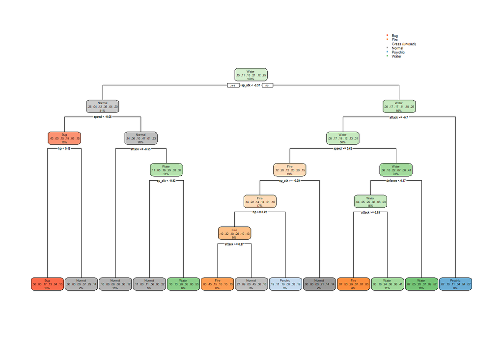

```r
best_complexity <- select_best(tune_res)

pokemon_tree_final <- finalize_workflow(pokemon_workflow, best_complexity)

pokemon_tree_final_fit <- fit(pokemon_tree_final, data = pokemon_train)

pokemon_tree_final_fit %>%
  extract_fit_engine() %>%
  rpart.plot()
```

## Excercise 5b

Random forest model and workflow.

```r
pokemon_forest_model <- rand_forest(mtry = tune(), trees = tune(), min_n = tune()) %>%
  set_engine("ranger", importance = "impurity") %>%
  set_mode("classification")

pokemon_forest_wf = workflow() %>%
  add_model(pokemon_forest_model) %>%
  add_recipe(pokemon_recipe)

param_grid_forest <- grid_regular(mtry(range = c(1, 8)), trees(range = c(10,1000)), min_n(range = c(1,50)), levels = 8)
```

We are tuning parameters *mtry*, *trees*, and *min_n*.

*mtry* is the number of predictors that will be sampled at each split when building trees. Our dataset has 8 predictors, so this sets a max on *mtry*, and at least one predictor is needed to split the data, so this sets a min.

*trees* is the total number of trees within the random forest model.

*min_n* is the smallest node size allowable. Nodes will not be split smaller than *min_n*

## Excercise 6

Tune models (5 folds x 8 mtry x 8 trees x 8 min_n = 2560 models) based on ROC AUC.

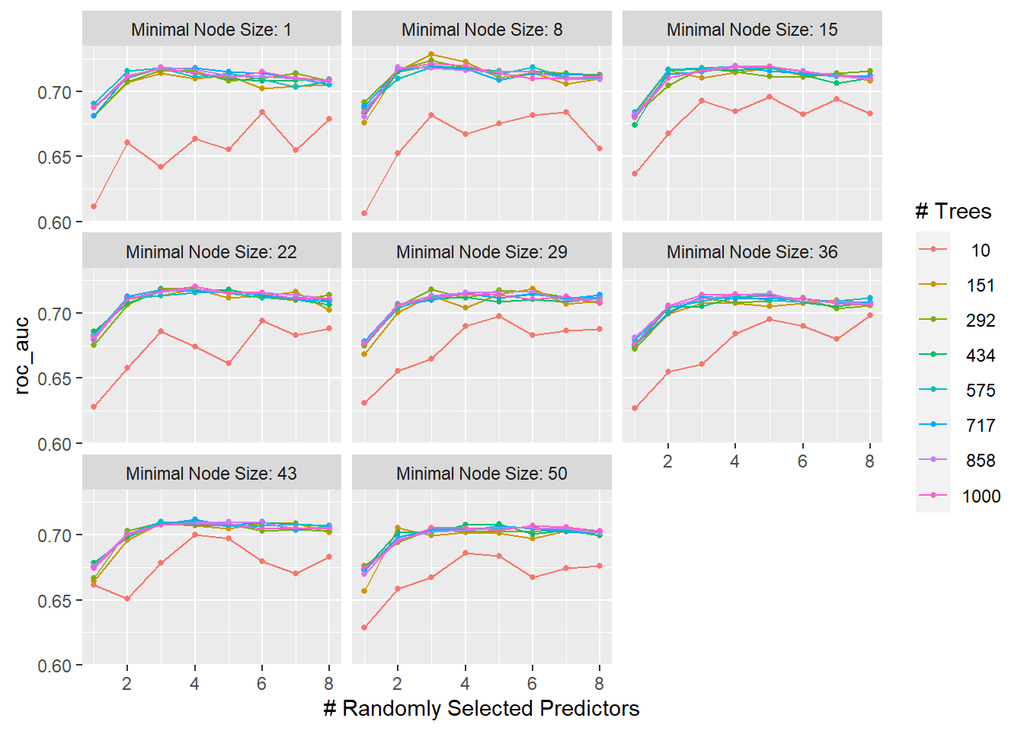

```r
tune_res_forest <- tune_grid(
  pokemon_forest_wf,
  resamples = pokemon_folds,
  grid = param_grid_forest,
  metrics = metric_set(roc_auc)
)

autoplot(tune_res_forest)
```

The best ROC AUC values were achieved by random forests with more than 1 randomly selected predictors, >40 Trees, and a minimum node size of <30.

## Excercise 7

ROC AUC of best performing mode.

```r
head(collect_metrics(tune_res_forest) %>% arrange(-mean))
```

```
## # A tibble: 6 × 9
##    mtry trees min_n .metric .estimator  mean     n std_err .config
##   <int> <int> <int> <chr>   <chr>      <dbl> <int>   <dbl> <chr>
## 1     3   151     8 roc_auc hand_till  0.728     5 0.00613 Preprocessor1_Model0…
## 2     3   292     8 roc_auc hand_till  0.723     5 0.00759 Preprocessor1_Model0…
## 3     4   151     8 roc_auc hand_till  0.722     5 0.00398 Preprocessor1_Model0…
## 4     3  1000     8 roc_auc hand_till  0.721     5 0.00701 Preprocessor1_Model1…
## 5     4  1000    22 roc_auc hand_till  0.720     5 0.00622 Preprocessor1_Model2…
## 6     4  1000     8 roc_auc hand_till  0.720     5 0.00537 Preprocessor1_Model1…
```

## Excercise 8

Variable Importance Plot (VIP) of best performing fit on training set.

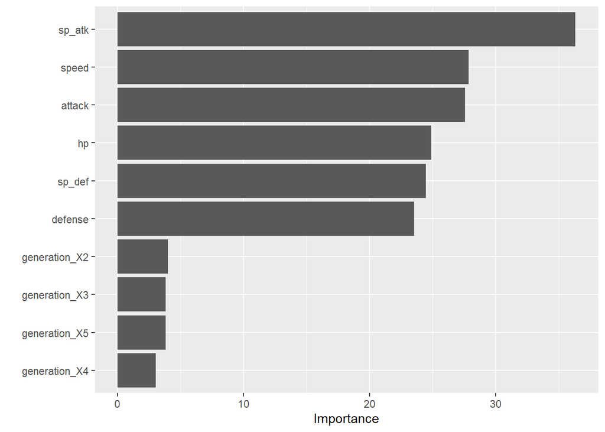

```r
best_params_forest <- select_best(tune_res_forest)

pokemon_forest_final <- finalize_workflow(pokemon_forest_wf, best_params_forest)

pokemon_forest_final_fit <- fit(pokemon_forest_final, data = pokemon_train)

vip(extract_fit_engine(pokemon_forest_final_fit))
```

sp_atk, speed, and attack were the most important predictors, and the generation dummy variables were least important. I expected that generation would be least important, and didn’t have expectations about the others.

## Excercise 9

Boosted Tree model and workflow, tuning *trees*.

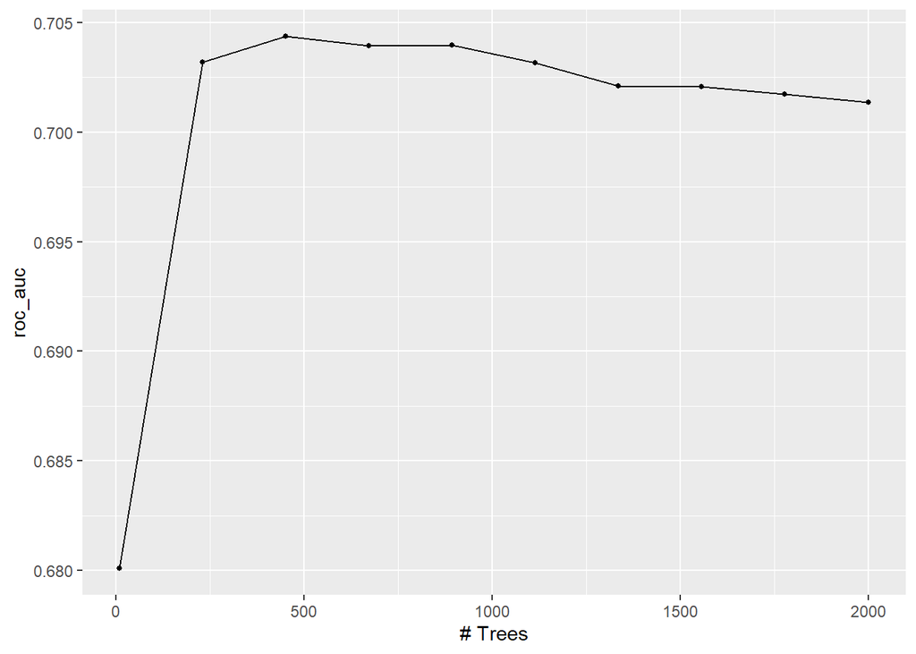

```r
pokemon_boost_model <- boost_tree(trees = tune()) %>%
  set_engine("xgboost") %>%
  set_mode("classification")

pokemon_boost_wf = workflow() %>%
  add_model(pokemon_boost_model) %>%
  add_recipe(pokemon_recipe)

param_grid_boost <- grid_regular(trees(range = c(10, 2000)), levels = 10)

tune_res_boost <- tune_grid(
  pokemon_boost_wf,
  resamples = pokemon_folds,
  grid = param_grid_boost,
  metrics = metric_set(roc_auc)
)

autoplot(tune_res_boost)
```

Model performance peaked around 500 trees, and very slightly declined approaching 2000.

```r
head(collect_metrics(tune_res_boost) %>% arrange(-mean))
```

```
## # A tibble: 6 × 7
##   trees .metric .estimator  mean     n std_err .config
##   <int> <chr>   <chr>      <dbl> <int>   <dbl> <chr>
## 1   452 roc_auc hand_till  0.704     5  0.0164 Preprocessor1_Model03
## 2   894 roc_auc hand_till  0.704     5  0.0161 Preprocessor1_Model05
## 3   673 roc_auc hand_till  0.704     5  0.0161 Preprocessor1_Model04
## 4   231 roc_auc hand_till  0.703     5  0.0155 Preprocessor1_Model02
## 5  1115 roc_auc hand_till  0.703     5  0.0156 Preprocessor1_Model06
## 6  1336 roc_auc hand_till  0.702     5  0.0156 Preprocessor1_Model07
```

The best performing model had 452 trees and an ROC AUC of .704